# census_ml

```python
import numpy as np
import pandas as pd
import matplotlib.pyplot as plt
import seaborn as sns
```

```python
df = pd.read_csv('CensusDB-1.csv')
df2 = pd.read_csv('CensusDB-1.csv')
df.head()
```

|  | age | workclass | fnlwgt | education | education-num | marital-status | occupation | relationship | sex | capital-gain | capital-loss | hours-per-week | native-country | income |
| --- | --- | --- | --- | --- | --- | --- | --- | --- | --- | --- | --- | --- | --- | --- |
| 0 | 90 | ? | 77053 | HS-grad | 9 | Widowed | ? | Not-in-family | Female | 0 | 4356 | 40 | United-States | <=50K |
| 1 | 82 | Private | 132870 | HS-grad | 9 | Widowed | Exec-managerial | Not-in-family | Female | 0 | 4356 | 18 | United-States | <=50K |
| 2 | 66 | ? | 186061 | Some-college | 10 | Widowed | ? | Unmarried | Female | 0 | 4356 | 40 | United-States | <=50K |
| 3 | 54 | Private | 140359 | 7th-8th | 4 | Divorced | Machine-op-inspct | Unmarried | Female | 0 | 3900 | 40 | United-States | <=50K |
| 4 | 41 | Private | 264663 | Some-college | 10 | Separated | Prof-specialty | Own-child | Female | 0 | 3900 | 40 | United-States | <=50K |

```python
df.tail()
```

|  | age | workclass | fnlwgt | education | education-num | marital-status | occupation | relationship | sex | capital-gain | capital-loss | hours-per-week | native-country | income |
| --- | --- | --- | --- | --- | --- | --- | --- | --- | --- | --- | --- | --- | --- | --- |
| 32556 | 22 | Private | 310152 | Some-college | 10 | Never-married | Protective-serv | Not-in-family | Male | 0 | 0 | 40 | United-States | <=50K |
| 32557 | 27 | Private | 257302 | Assoc-acdm | 12 | Married-civ-spouse | Tech-support | Wife | Female | 0 | 0 | 38 | United-States | <=50K |
| 32558 | 40 | Private | 154374 | HS-grad | 9 | Married-civ-spouse | Machine-op-inspct | Husband | Male | 0 | 0 | 40 | United-States | >50K |
| 32559 | 58 | Private | 151910 | HS-grad | 9 | Widowed | Adm-clerical | Unmarried | Female | 0 | 0 | 40 | United-States | <=50K |
| 32560 | 22 | Private | 201490 | HS-grad | 9 | Never-married | Adm-clerical | Own-child | Male | 0 | 0 | 20 | United-States | <=50K |

```python
df.info()
```

```
<class 'pandas.core.frame.DataFrame'>
RangeIndex: 32561 entries, 0 to 32560
Data columns (total 14 columns):
 #   Column          Non-Null Count  Dtype
---  ------          --------------  -----
 0   age             32561 non-null  int64
 1   workclass       32561 non-null  object
 2   fnlwgt          32561 non-null  int64
 3   education       32561 non-null  object
 4   education-num   32561 non-null  int64
 5   marital-status  32561 non-null  object
 6   occupation      32561 non-null  object
 7   relationship    32561 non-null  object
 8   sex             32561 non-null  object
 9   capital-gain    32561 non-null  int64
 10  capital-loss    32561 non-null  int64
 11  hours-per-week  32561 non-null  int64
 12  native-country  32561 non-null  object
 13  income          32561 non-null  object
dtypes: int64(6), object(8)
memory usage: 3.5+ MB
```

```python
df.workclass.unique()
```

```
array(['?', 'Private', 'State-gov', 'Federal-gov', 'Self-emp-not-inc',
       'Self-emp-inc', 'Local-gov', 'Without-pay', 'Never-worked'],
      dtype=object)
```

```python
df.occupation.unique()
```

```
array(['?', 'Exec-managerial', 'Machine-op-inspct', 'Prof-specialty',
       'Other-service', 'Adm-clerical', 'Craft-repair',
       'Transport-moving', 'Handlers-cleaners', 'Sales',
       'Farming-fishing', 'Tech-support', 'Protective-serv',
       'Armed-Forces', 'Priv-house-serv'], dtype=object)
```

```python
df.income.unique()
```

```
array(['<=50K', '>50K'], dtype=object)
```

```python
df['income'] = df['income'].map({'<=50K': 0, '>50K': 1})
df2['income'] = df2['income'].map({'<=50K': 0, '>50K': 1})
```

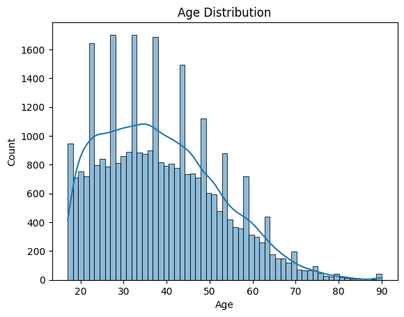

```python
# Distribution of age
sns.histplot(df['age'], kde=True)
plt.title('Age Distribution')
plt.xlabel('Age')
plt.ylabel('Count')
plt.show()
```

```python
df[df.income == 0].count()
```

```
age               24720
workclass         24720
fnlwgt            24720
education         24720
education-num     24720
marital-status    24720
occupation        24720
relationship      24720
sex               24720
capital-gain      24720
capital-loss      24720
hours-per-week    24720
native-country    24720
income            24720
dtype: int64
```

```python
df.age.value_counts()
```

```
age
36    898
31    888
34    886
23    877
35    876
     ...
83      6
88      3
85      3
86      1
87      1
Name: count, Length: 73, dtype: int64
```

```python
df['education'] = df['education'].str.strip()
```

```python
df.education.unique()
```

```
array(['HS-grad', 'Some-college', '7th-8th', '10th', 'Doctorate',
       'Prof-school', 'Bachelors', 'Masters', '11th', 'Assoc-acdm',
       'Assoc-voc', '1st-4th', '5th-6th', '12th', '9th', 'Preschool'],
      dtype=object)
```

```python
df.info()
```

```
<class 'pandas.core.frame.DataFrame'>
RangeIndex: 32561 entries, 0 to 32560
Data columns (total 14 columns):
 #   Column          Non-Null Count  Dtype
---  ------          --------------  -----
 0   age             32561 non-null  int64
 1   workclass       32561 non-null  object
 2   fnlwgt          32561 non-null  int64
 3   education       32561 non-null  object
 4   education-num   32561 non-null  int64
 5   marital-status  32561 non-null  object
 6   occupation      32561 non-null  object
 7   relationship    32561 non-null  object
 8   sex             32561 non-null  object
 9   capital-gain    32561 non-null  int64
 10  capital-loss    32561 non-null  int64
 11  hours-per-week  32561 non-null  int64
 12  native-country  32561 non-null  object
 13  income          32561 non-null  int64
dtypes: int64(7), object(7)
memory usage: 3.5+ MB
```

```python
df['marital-status'].unique()
```

```
array(['Widowed', 'Divorced', 'Separated', 'Never-married',
       'Married-civ-spouse', 'Married-spouse-absent', 'Married-AF-spouse'],
      dtype=object)
```

```python
#conveting marital-status categorical data to numerical data
marital_status_mapping = {
    'Widowed': 0,
    'Divorced': 1,
    'Separated': 2,
    'Never-married': 3,
    'Married-civ-spouse': 4,
    'Married-spouse-absent': 5,
    'Married-AF-spouse': 6
}


df['marital-status'] = df['marital-status'].map(marital_status_mapping)
```

```python
df.workclass.unique()
```

```
array(['?', 'Private', 'State-gov', 'Federal-gov', 'Self-emp-not-inc',
       'Self-emp-inc', 'Local-gov', 'Without-pay', 'Never-worked'],
      dtype=object)
```

```python
#converting workclass categorical data to numerical data
workclass_mapping = {
    '?': 0,
    'Private': 1,
    'State-gov': 2,
    'Federal-gov': 3,
    'Self-emp-not-inc': 4,
    'Self-emp-inc': 5,
    'Local-gov': 6,
    'Without-pay': 7,
    'Never-worked': 8
}

df['workclass'] = df['workclass'].map(workclass_mapping)
```

```python
df.occupation.unique()
```

```
array(['?', 'Exec-managerial', 'Machine-op-inspct', 'Prof-specialty',
       'Other-service', 'Adm-clerical', 'Craft-repair',
       'Transport-moving', 'Handlers-cleaners', 'Sales',
       'Farming-fishing', 'Tech-support', 'Protective-serv',
       'Armed-Forces', 'Priv-house-serv'], dtype=object)
```

```python
#converting occupation categorical data to numerical data
occupation_mapping = {
    '?': 0,
    'Exec-managerial': 1,
    'Machine-op-inspct': 2,
    'Prof-specialty': 3,
    'Other-service': 4,
    'Adm-clerical': 5,
    'Craft-repair': 6,
    'Transport-moving': 7,
    'Handlers-cleaners': 8,
    'Sales': 9,
    'Farming-fishing': 10,
    'Tech-support': 11,
    'Protective-serv': 12,
    'Armed-Forces': 13,
    'Priv-house-serv': 14
}

df['occupation'] = df['occupation'].map(occupation_mapping)
```

```python
df.relationship.unique()
```

```
array(['Not-in-family', 'Unmarried', 'Own-child', 'Other-relative',
       'Husband', 'Wife'], dtype=object)
```

```python
#converting relationship categorical data to numerical data
relationship_mapping = {
    'Not-in-family': 0,
    'Unmarried': 1,
    'Own-child': 2,
    'Other-relative': 3,
    'Husband': 4,
    'Wife': 5
}

df['relationship'] = df['relationship'].map(relationship_mapping)
```

```python
df.sex.unique()
```

```
array(['Female', 'Male'], dtype=object)
```

```python
#converting sex categorical data to numerical data
sex_mapping = {
    'Female': 0,
    'Male': 1
}
df['sex'] = df['sex'].map(sex_mapping)
```

```python
df['native-country'].unique()
```

```
array(['United-States', '?', 'Mexico', 'Greece', 'Vietnam', 'China',
       'Taiwan', 'India', 'Philippines', 'Trinadad&Tobago', 'Canada',
       'South', 'Holand-Netherlands', 'Puerto-Rico', 'Poland', 'Iran',
       'England', 'Germany', 'Italy', 'Japan', 'Hong', 'Honduras', 'Cuba',
       'Ireland', 'Cambodia', 'Peru', 'Nicaragua', 'Dominican-Republic',
       'Haiti', 'El-Salvador', 'Hungary', 'Columbia', 'Guatemala',
       'Jamaica', 'Ecuador', 'France', 'Yugoslavia', 'Scotland',
       'Portugal', 'Laos', 'Thailand', 'Outlying-US(Guam-USVI-etc)'],
      dtype=object)
```

```python
#converting native-country categorical data to numerical data
country_mapping = {
    'United-States': 0,
    '?': 1,
    'Mexico': 2,
    'Greece': 3,
    'Vietnam': 4,
    'China': 5,
    'Taiwan': 6,
    'India': 7,
    'Philippines': 8,
    'Trinadad&Tobago': 9,
    'Canada': 10,
    'South': 11,
    'Holand-Netherlands': 12,
    'Puerto-Rico': 13,
    'Poland': 14,
    'Iran': 15,
    'England': 16,
    'Germany': 17,
    'Italy': 18,
    'Japan': 19,
    'Hong': 20,
    'Honduras': 21,
    'Cuba': 22,
    'Ireland': 23,
    'Cambodia': 24,
    'Peru': 25,
    'Nicaragua': 26,
    'Dominican-Republic': 27,
    'Haiti': 28,
    'El-Salvador': 29,
    'Hungary': 30,
    'Columbia': 31,
    'Guatemala': 32,
    'Jamaica': 33,
    'Ecuador': 34,
    'France': 35,
    'Yugoslavia': 36,
    'Scotland': 37,
    'Portugal': 38,
    'Laos': 39,
    'Thailand': 40,
    'Outlying-US(Guam-USVI-etc)': 41
}

df['native-country'] = df['native-country'].map(country_mapping)
```

```python
df.info()
```

```
<class 'pandas.core.frame.DataFrame'>
RangeIndex: 32561 entries, 0 to 32560
Data columns (total 14 columns):
 #   Column          Non-Null Count  Dtype
---  ------          --------------  -----
 0   age             32561 non-null  int64
 1   workclass       32561 non-null  int64
 2   fnlwgt          32561 non-null  int64
 3   education       32561 non-null  object
 4   education-num   32561 non-null  int64
 5   marital-status  32561 non-null  int64
 6   occupation      32561 non-null  int64
 7   relationship    32561 non-null  int64
 8   sex             32561 non-null  int64
 9   capital-gain    32561 non-null  int64
 10  capital-loss    32561 non-null  int64
 11  hours-per-week  32561 non-null  int64
 12  native-country  32561 non-null  int64
 13  income          32561 non-null  int64
dtypes: int64(13), object(1)
memory usage: 3.5+ MB
```

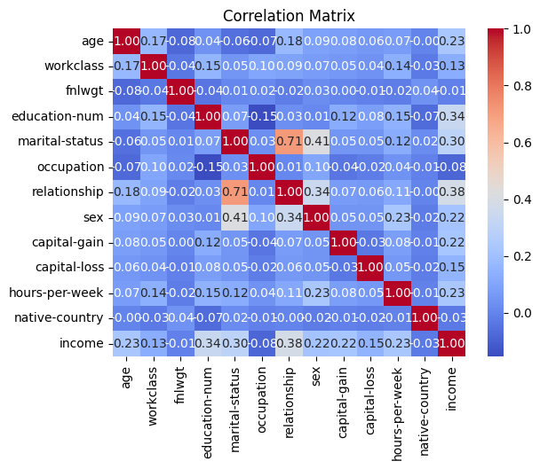

```python
# Correlation matrix (for numerical features)
corr_df = df.drop(columns= ['education'])
correlation_matrix = corr_df.corr()
sns.heatmap(correlation_matrix, annot=True, cmap='coolwarm', fmt=".2f")
plt.title('Correlation Matrix')
plt.show()
```

```python
correlation = corr_df.corr()['income'].sort_values(ascending= False)
correlation
```

```
income            1.000000
relationship      0.380359
education-num     0.335154
marital-status    0.296935
age               0.234037
hours-per-week    0.229689
capital-gain      0.223329
sex               0.215980
capital-loss      0.150526
workclass         0.128308
fnlwgt           -0.009463
native-country   -0.029391
occupation       -0.084696
Name: income, dtype: float64
```

Based on the correlation value:

1. Relationship (0.380359), Education (0.335154), and Marital Status (0.296935) have the highest positive correlations with Income. This suggests that there is a positive relationship between these features and the target variable. For example, individuals with higher Education tend to have higher incomes.
2. Age (0.234037) and Working Hours (0.229689) also have a moderate positive correlation with Income. This indicates that as age and hours worked per week increase, there is a tendency for income to increase as well.
3. Capital-gain (0.223329), Sex (0.215980), and Capital-loss (0.150526) show positive correlations with Income, but they are weaker compared to the previously mentioned features.
4. Working class (0.128308) has a weak positive correlation with Income. It implies that certain workclasses might be associated with slightly higher incomes than others.
5. 'fnlwgt' (-0.009463) and Native Country (-0.029391) have very low correlations with Income, indicating a weak relationship or no linear relationship at all.
6. Occupation (-0.084696) has a weak negative correlation with Income. It suggests that certain occupations might be associated with slightly lower incomes.

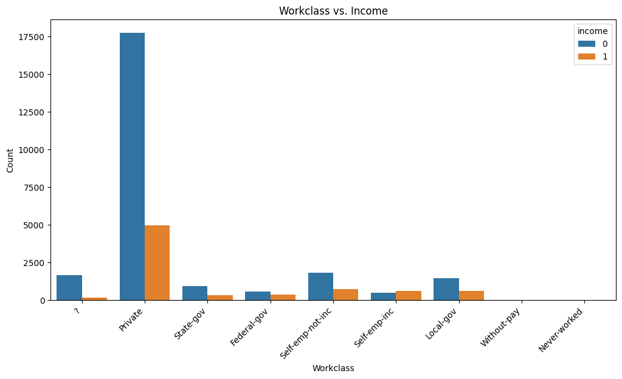

```python
# Count plot for workclass vs. income
plt.figure(figsize=(12, 6))
sns.countplot(x='workclass', hue='income', data=df2)
plt.title('Workclass vs. Income')
plt.xlabel('Workclass')
plt.ylabel('Count')
plt.xticks(rotation=45, ha='right')
plt.show()
```

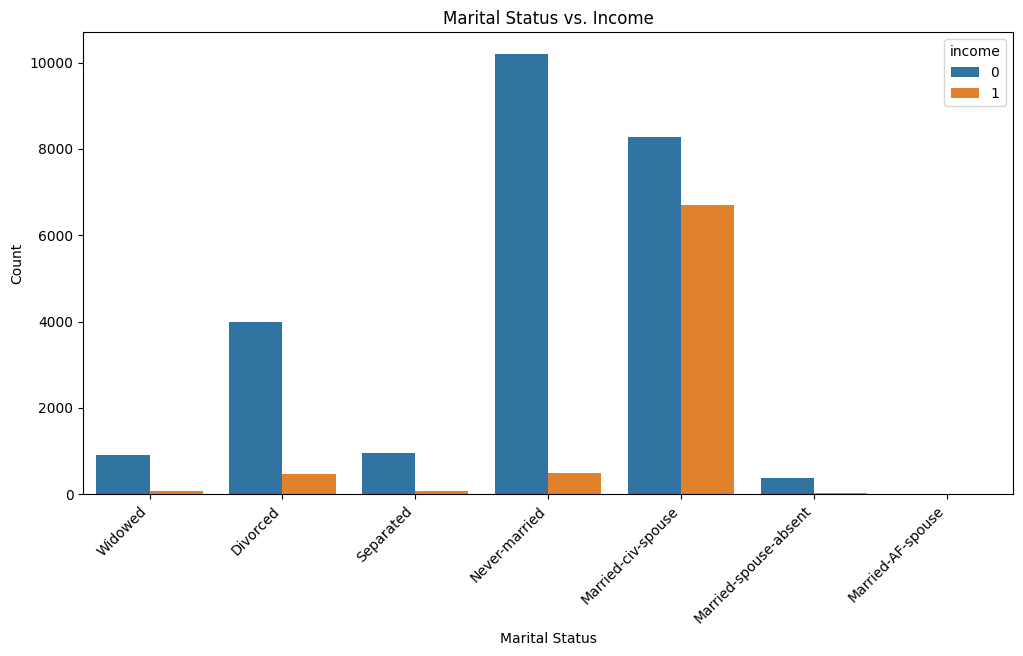

```python
# Count plot for marital-status vs. income
plt.figure(figsize=(12, 6))
sns.countplot(x='marital-status', hue='income', data=df2)
plt.title('Marital Status vs. Income')
plt.xlabel('Marital Status')
plt.ylabel('Count')
plt.xticks(rotation=45, ha='right')
plt.show()
```

Assumptions

1. Logistic Regression:
   - Assumption: The relationship between the features and the target variable ('income') is approximately linear. Logistic Regression is chosen as a simple and interpretable model for binary classification tasks where the decision boundary is expected to be linear.
2. Random Forest Classifier:
   - Assumption: The relationship between the features and the target variable can be non-linear and may involve complex interactions. Random Forest is chosen as an ensemble method capable of capturing non-linear relationships and interactions in the data.
3. Multi-Layer Perceptron (MLP) Classifier:
   - Assumption: The problem may involve learning complex patterns and representations from the data. MLPs, as deep neural networks, can discover intricate relationships in the features and automatically extract relevant feature representations from the hidden layers.
4. K-Means Clustering:
   - Assumption: There may exist underlying natural groupings in the data, and we want to discover them without using labeled data. K-Means is chosen for its simplicity and ability to cluster data based on similarity without requiring labeled examples.
5. Decision Tree Classifier:
   - Assumption: The problem requires interpretability and the ability to visualize the decision-making process. Decision Trees are chosen for their transparent nature, allowing us to interpret the decision rules used to classify individuals based on feature values.

Machine Learning Models

```python
from sklearn.model_selection import train_test_split
```

```python
# Separating features and target variable
X = corr_df.drop('income', axis=1)
Y = corr_df['income']
```

```python
# Spliting the data into training and testing sets (80% train, 20% test)
X_train, X_test, Y_train, Y_test = train_test_split(X, Y, test_size=0.2, random_state=50)
```

Classification Models:

1. Logistic Regression:

```python
from sklearn.linear_model import LogisticRegression
from sklearn.metrics import accuracy_score
```

```python
# Training Logistic Regression model
logistic_model = LogisticRegression(random_state=50)
logistic_model.fit(X_train, Y_train)
```

```
LogisticRegression(random_state=50)
```

```python
# Making predictions on the test set
Y_pred_logistic = logistic_model.predict(X_test)
```

```python
logistic_accuracy = accuracy_score(Y_test, Y_pred_logistic)
result = "Logistic Regression Accuracy:", logistic_accuracy
result
```

```
('Logistic Regression Accuracy:', 0.7991708889912482)
```

2. Random Forest Classifier:

```python
from sklearn.ensemble import RandomForestClassifier
```

```python
# Training Random Forest Classifier model
rf_model = RandomForestClassifier(random_state=50)
rf_model.fit(X_train, Y_train)
```

```
RandomForestClassifier(random_state=50)
```

```python
# Making predictions on the test set
Y_pred_rf = rf_model.predict(X_test)
```

```python
rf_accuracy = accuracy_score(Y_test, Y_pred_rf)
result ="Random Forest Accuracy:", rf_accuracy
result
```

```
('Random Forest Accuracy:', 0.857976354982343)
```

K-Means Clustering:

```python
from sklearn.cluster import KMeans
from sklearn.metrics import silhouette_score
import warnings
warnings.filterwarnings('ignore')
```

```python
# Training the K-Means Clustering model
kmeans_model = KMeans(n_clusters=2, random_state=50)
kmeans_model.fit(X)
```

```
KMeans(n_clusters=2, random_state=50)
```

```python
# Making predictions on the test set
Y_pred_kmeans = kmeans_model.predict(X)
```

```python
silhouette_score_result = silhouette_score(X, Y_pred_kmeans)
result = "Silhouette Score:", silhouette_score_result
result
```

```
('Silhouette Score:', 0.5858927275795555)
```

Multi-Layer Perceptron (MLP) Classifier:

```python
from sklearn.neural_network import MLPClassifier
```

```python
mlp_model = MLPClassifier(hidden_layer_sizes=(100, 50), max_iter=1200, random_state=50)
mlp_model.fit(X_train, Y_train)
```

```
MLPClassifier(hidden_layer_sizes=(100, 50), max_iter=1200, random_state=50)
```

```python
# Making predictions on the test set
Y_pred_mlp = mlp_model.predict(X_test)
```

```python
mlp_accuracy = accuracy_score(Y_test, Y_pred_mlp)
result = "MLP Classifier Accuracy:", mlp_accuracy
result
```

```
('MLP Classifier Accuracy:', 0.787655458314141)
```

Decision Tree Classifier

```python
from sklearn.tree import DecisionTreeClassifier
```

```python
# Training Decision Tree Classifier model
dt_model = DecisionTreeClassifier(random_state=50)
dt_model.fit(X_train, Y_train)
```

```
DecisionTreeClassifier(random_state=50)
```

```python
# Making predictions on the test set
Y_pred_dt = dt_model.predict(X_test)
```

```python
dt_accuracy = accuracy_score(Y_test, Y_pred_dt)
result = "Decision Tree Accuracy:", dt_accuracy
result
```

```
('Decision Tree Accuracy:', 0.8136035621065562)
```

Model Comparison

Logistic Regression vs. Random Forest Classifier

1. Accuracy Comparison:
   - Logistic Regression Accuracy: 0.7992
   - Random Forest Accuracy: 0.8580

   Based on the accuracy scores alone, the Random Forest Classifier outperforms Logistic Regression with a higher accuracy.
2. Model Interpretability:
   - Logistic Regression: The optimized Logistic Regression model achieved an accuracy of approximately 0.799, indicating that it performed reasonably well in predicting whether an individual earns more than $50,000 annually or not.
   - Random Forest, on the other hand, is an ensemble model composed of multiple decision trees, which can be more challenging to interpret. While feature importance can be extracted from Random Forest, it might not be as straightforward as in Logistic Regression.
3. Generalization Performance:
   - Random Forest tends to have better generalization performance compared to Logistic Regression, because it can capture non-linear relationships and interactions between features, making it more capable of handling intricate patterns in the data.
4. Training and Inference Time:
   - Logistic Regression is generally faster to train and make predictions compared to Random Forest.

Considering the above factors, if interpretability and speed are critical, and the dataset has a relatively simple relationship between features and the target, Logistic Regression is the suitable choice. On the other hand, if accuracy and handling complex relationships in the data are essential, Random Forest would be a better option.

MLP Classifier vs. Decision Tree classifier

1. Accuracy Comparison:
   - MLP Classifier Accuracy: 0.7877
   - Decision Tree Accuracy: 0.8136

   Based on the accuracy scores, the Decision Tree Classifier has a slightly higher accuracy compared to the MLP Classifier.
2. Model Interpretability:
   - Decision Tree Classifier is relatively more interpretable than MLP Classifier. Since Decision Trees creates a set of simple if-else rules, making it easier to understand how the model arrives at its predictions.
   - MLP Classifier, being a neural network, is more complex and less interpretable than Decision Trees. Neural networks involve multiple layers of interconnected neurons, which can make it challenging to explain their decision-making process.
3. Generalization Performance:
   - Decision Tree Classifier are most likely prone to overfitting, especially on complex datasets. This can create very deep trees that capture noise in the training data and may not generalize well to unseen data.
   - MLP Classifier, being a neural network, can also be susceptible to overfitting, particularly with large networks and insufficient regularization. However, it can potentially capture more complex patterns in the data, leading to better generalization when trained on an adequate amount of data.
4. Training and Inference Time:
   - Decision Tree Classifier is faster to train compared to MLP Classifier.

Considering the above factors, if interpretability and simplicity are crucial, and the dataset is relatively simple, the Decision Tree Classifier might be a suitable choice. On the other hand, if there is a need for a more complex model capable of capturing intricate relationships in the data, and there is sufficient data available to avoid overfitting, the MLP Classifier could be preferred.

Overall Conclusion

Overall, the Random Forest model performed the best in terms of accuracy, indicating its ability to handle the complexity of the dataset and capture relevant patterns effectively. However, the choice of the best model ultimately depends on the specific use case, interpretability requirements, and other considerations, such as computational resources and the need for feature importance insights.